# Machine Learning - Classification of weight lifting excercises

gunbra

March 21, 2015

This document describes the procedure I followed to predict the quality of barbell lifts using data from accelerometers on the belt, forearm, arm, and dumbell of 6 participants. To that end, two data sets, one for training and one for testing, with 152 predictors are loaded. The training data set is then further separated into a subset applied in the training of the predictive model (called train_train herafter) and a much smaller subset for estimating the out-of-sample error (called train_test hereafter).

```r
testing <- read.csv("pml-testing.csv",na.strings = c("NA", "na", "NULL",
                                                     "null", ""))
training <- read.csv("pml-training.csv",na.strings = c("NA", "na", "NULL",
                                                      "null", ""))
itrain <- createDataPartition(training$classe,p=.9,list=FALSE)
train_test <- training[-itrain,]
train_train <- training[itrain,]
```

Before training a predictive model, the training data set is reduced by the majority of predictors. In particular, all predictors with low variance, here setting freqCut to 70/30 and uniqueCut to 20, are discarded. Furthermore, all columns that only contain NAs and the first seven columns containing participants’ names and time information are also eliminated. Eventually, 45 predictors are remaining.

```r
ii <- nearZeroVar(train_train,freqCut=70/30,uniqueCut=20)
t1 <- train_train[,-ii]
t1 <- t1[,colSums(is.na(t1))<1]
t1 <- t1[,c(-1,-2,-3,-4,-5,-6,-7)]
```

Then, a random forest model is trained to the training data applying a repeated K-fold cross-validation with k = 10 and 20 repetitions. Cross validation was, thus, already used during the training process.

```r
ctrl <- trainControl(method = "repeatedcv", number = 10, repeats = 20)
fit <-train(classe ~ . ,data=t1, method="rf",ntree=50, trControl=ctrl)
fit
```

```
## Random Forest
##
## 17662 samples
##    45 predictor
##     5 classes: 'A', 'B', 'C', 'D', 'E'
##
## No pre-processing
## Resampling: Cross-Validated (10 fold, repeated 20 times)
##
## Summary of sample sizes: 15894, 15896, 15895, 15895, 15897, 15896, ...
##
## Resampling results across tuning parameters:
##
##   mtry  Accuracy   Kappa      Accuracy SD  Kappa SD
##    2    0.9899388  0.9872711  0.002599414  0.003289628
##   23    0.9923337  0.9903020  0.002263007  0.002863324
##   45    0.9894829  0.9866957  0.002432412  0.003077800
##
## Accuracy was used to select the optimal model using  the largest value.
## The final value used for the model was mtry = 23.
```

The final model performed very well in predicitng the classification of the exercises in the data_set train_train. Accuracy and kappa were both above 0.99 indicating an almost perfect model performance. The out-of-sample error of the model is expected to be slightly lower than this value. The final model has mtry=23 randomly selected predictors at each split.

```r
fit$finalModel
```

```
##
## Call:
##  randomForest(x = x, y = y, ntree = 50, mtry = param$mtry)
##                Type of random forest: classification
##                      Number of trees: 50
## No. of variables tried at each split: 23
##
##         OOB estimate of  error rate: 0.83%
## Confusion matrix:
##      A    B    C    D    E class.error
## A 5003    8    2    8    1 0.003783353
## B   29 3368   17    1    3 0.014628438
## C    3   15 3054    8    0 0.008441558
## D    4    0   34 2855    2 0.013816926
## E    0    2    2    8 3235 0.003695719
```

A closer inspection of the final model reveals that the missclassifiactions are distributed almost evenly among all five classes and that the error is smaller than 0.015 even for the worst case, i.e. for class B.

```r
ps <- predict(fit,train_test)
confusionMatrix(ps,train_test$classe)
```

```
## Confusion Matrix and Statistics
##
##           Reference
## Prediction   A   B   C   D   E
##          A 557   6   0   0   1
##          B   0 373   4   0   0
##          C   0   0 337   1   1
##          D   1   0   1 319   1
##          E   0   0   0   1 357
##
## Overall Statistics
##
##                Accuracy : 0.9913
##                  95% CI : (0.9861, 0.9949)
##     No Information Rate : 0.2847
##     P-Value [Acc > NIR] : < 2.2e-16
##
##                   Kappa : 0.989
##  Mcnemar's Test P-Value : NA
##
## Statistics by Class:
##
##                      Class: A Class: B Class: C Class: D Class: E
## Sensitivity            0.9982   0.9842   0.9854   0.9938   0.9917
## Specificity            0.9950   0.9975   0.9988   0.9982   0.9994
## Pos Pred Value         0.9876   0.9894   0.9941   0.9907   0.9972
## Neg Pred Value         0.9993   0.9962   0.9969   0.9988   0.9981
## Prevalence             0.2847   0.1934   0.1745   0.1638   0.1837
## Detection Rate         0.2842   0.1903   0.1719   0.1628   0.1821
## Detection Prevalence   0.2878   0.1923   0.1730   0.1643   0.1827
## Balanced Accuracy      0.9966   0.9908   0.9921   0.9960   0.9955
```

```r
varImp(fit,scale=TRUE)
```

[output not shown]

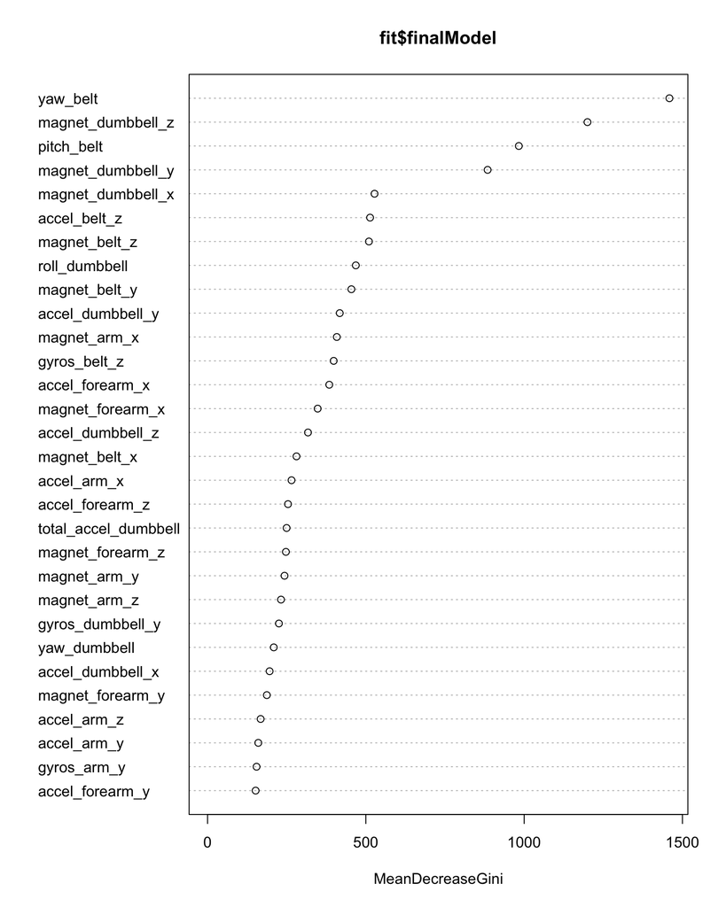

```r
varImpPlot(fit$finalModel)
```